# Practical_Computing_final_project

Robert Cooper

March 19, 2015

# Determining Gene Ontology with Large Sequence Libraries

## please check my github repository: https://github.com/rdcooper408/project_hw2

For my project i embarked on a wonderful journey to shame my computer and eventually unlock the secrets that RNA sequences hold. I began with a simple question that quickly evolved into a thought provoking and challenging series of solutions which would test the very fabric of my computing soul. I enjoyed the journey very much and learned a lot more than i could have imagined as a young 2nd quarter graduate student, though it seems like such a distant memory i would like to take the opportunity to regale you with my trials and triumphs through the error ridden land of my computers CPU.

My project had two main goals; Firstly, i wanted to gain comfortability with manipulating large datasets and gain insight into how to manipulate these unwieldy files, and get them to behave properly through my own very poorly written code. Secondly, i wanted to run all the way from sequence read outputs to mapping gene functions in order to get a hands on experience that would help me later when i construct my own RNA libraries.

# The data

I received 1.14 million RNA transcripts from a collaborator so that i can practice working through these huge datasets while still working on a close relative, and therefore applicable sister species to the one that i plan to study for my PhD. This fasta file needed to be trimmed down before further processing, for i learned that cranking through 1 million sequences was easier said than done…

Example: - **>contig00001 length=239 numreads=210 gene=isogroup00001 status=ig_thresh** CAGGTACTAGAGTATGGTCTCGAAAGTAGAGCGTAGGGAAAGCCCTGCGCATGCGTATTCTCGATTCGGAGGCGCCAGTTGAGGGCG - **>contig00002 length=244 numreads=4 gene=isogroup00001 status=ig_thresh** TAAGTTTTTCACATCTTTTCTACTGTTCAGTACTAGATTGTTGGGATTCTGcGCATCCTTATTGTCTATTGATAACCcTTCCTTtGCT - **>contig00003 length=1910 numreads=1812 gene=isogroup00001 status=ig_thresh** AGTTCAAGGAGGCATTCTCACTCTTTGACAAAGATGGTGATGGCACCATTACTACTAAGGAGCTGGGTACTGTCATGAGGTCGCTGGG - **>contig00004 length=1872 numreads=850 gene=isogroup00001 status=ig_thresh** GCCCATTCAGACgCCAGCGGCCCGCAGACAGATACCAgccccTGTCCCGAAACAAGCGCACGGAGCACCGCGACGACGAGCAGGCACA

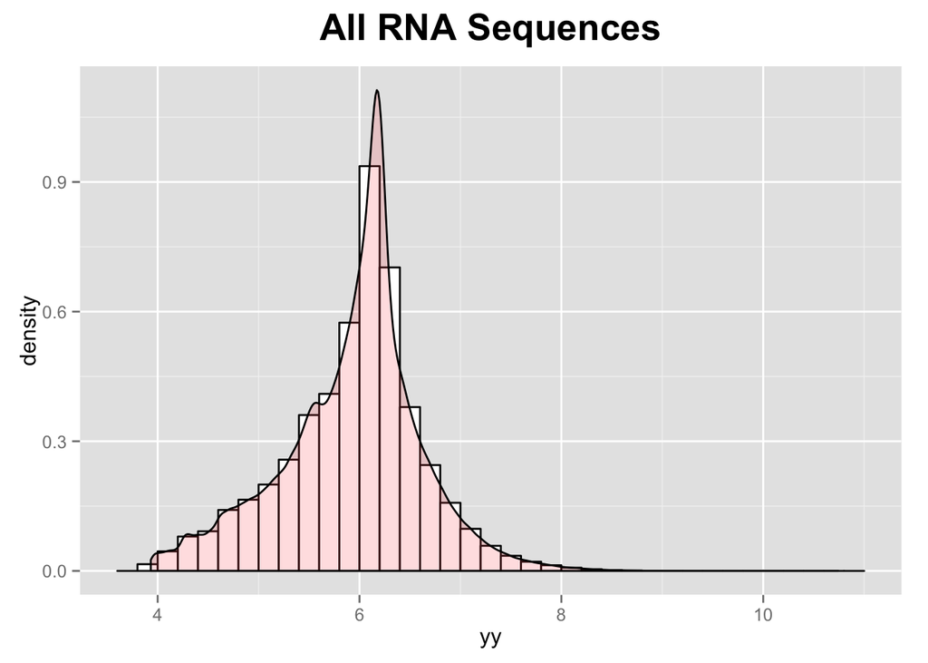

```r
yy <- log(amex_Tlen[,2])
ggplot(as.data.frame(yy), aes(x=yy)) + geom_histogram(aes(y=..density..), binwidth=.2, color="black", fill="white") + geom_density(alpha=.2, fill="#FF6666") + ggtitle('All RNA Sequences') + theme(plot.title = element_text(size=20, face="bold", vjust=2))
```

# Clustering (CD-HIT)

```python
# run the code on the actual mexicanum transcripts
  ./cd-hit-est -i 454ctgmexgt50.fas -o amex_cluster_90-100 -c 0.95 -n 8

    # run for less of a threshold
    ./cd-hit-est -i 454ctgmexgt50.fas -o amex_cluster_80 -c 0.80 -n 5
```

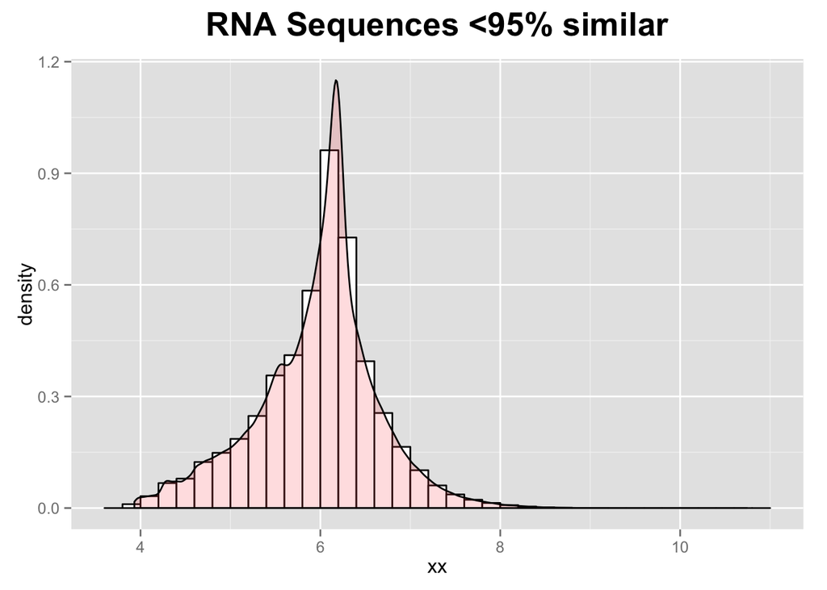

```r
xx <- log(amex_Tlen[,3])
ggplot(as.data.frame(xx), aes(x=xx)) + geom_histogram(aes(y=..density..), binwidth=.2, color="black", fill="white") + geom_density(alpha=.2, fill="#FF6666") + ggtitle('RNA Sequences <95% similar') + theme(plot.title = element_text(size=20, face="bold", vjust=2))
```

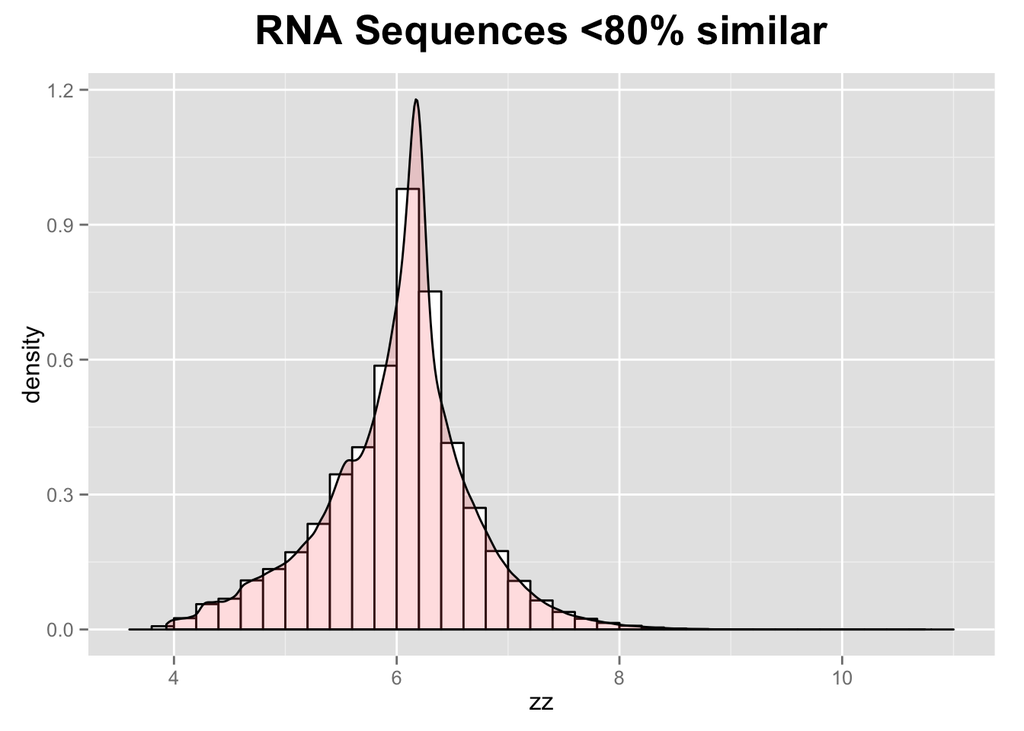

[figure not shown]

```r
zz <- log(amex_Tlen[,4])
ggplot(as.data.frame(zz), aes(x=zz)) + geom_histogram(aes(y=..density..), binwidth=.2, color="black", fill="white") + geom_density(alpha=.2, fill="#FF6666") + ggtitle('RNA Sequences <80% similar') + theme(plot.title = element_text(size=20, face="bold", vjust=2))
```

## Sequences Removed

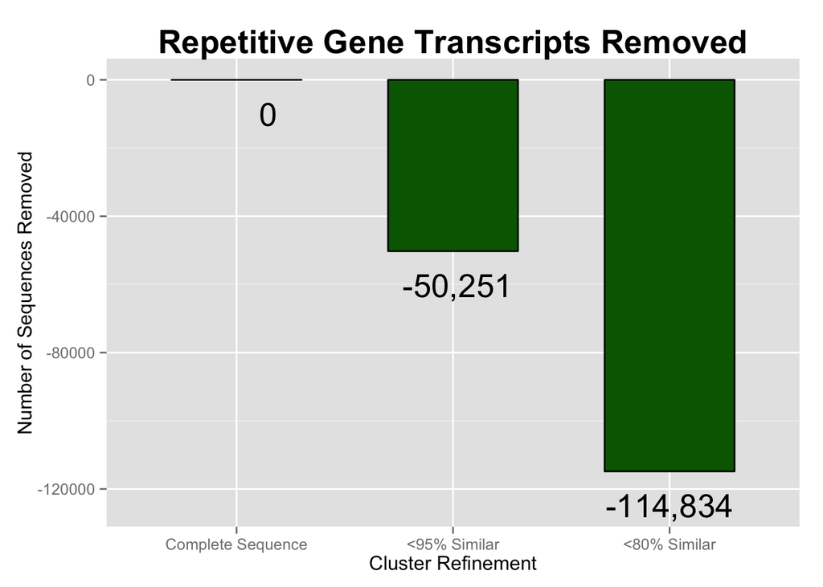

## Percent Removed

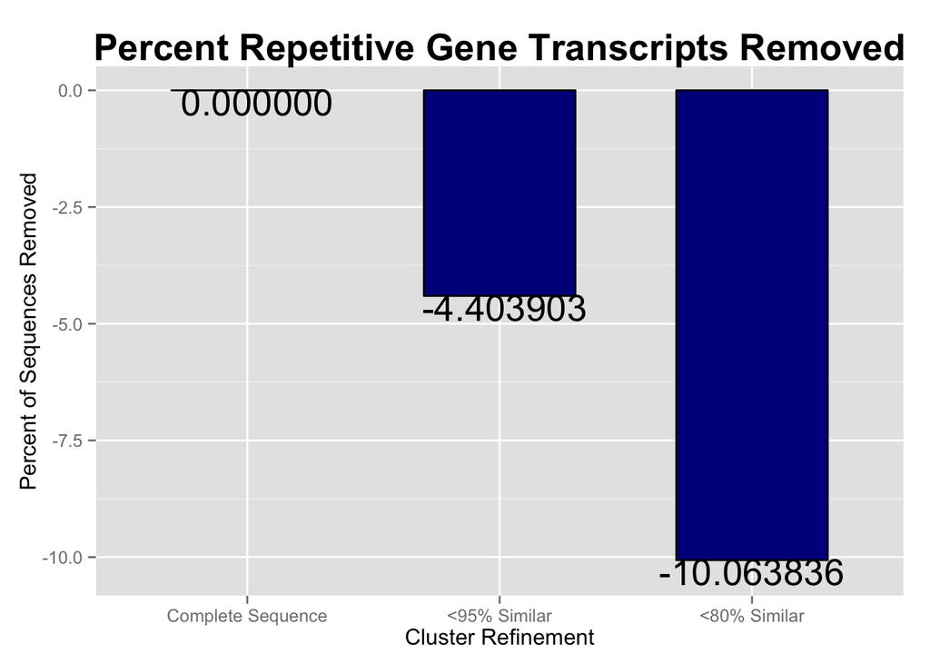

## Install Biopython

```python
## If you want the documentation and unit tests,
sudo apt-get install python-biopython-doc

## And if you want to use BioSQL,
sudo apt-get install python-biopython-sql
```

## Translated these sequences to proteins

```python
from Bio.Seq import Seq
from Bio import SeqIO
from Bio.SeqRecord import SeqRecord

def translate_seq(input_file, output_file, input_file_type = "fasta", output_file_type = "fasta"):

    def make_protein_record(nuc_record):
        """Returns a new SeqRecord with the translated sequence (default table)."""
        return SeqRecord(seq = nuc_record.seq.translate(to_stop=True), \
            id = "trans_" + nuc_record.id, \
            description = "translation of CDS, using default table")

    proteins = (make_protein_record(nuc_rec) for nuc_rec in \
        SeqIO.parse(input_file, input_file_type))

    SeqIO.write(proteins, output_file, output_file_type)
```

## Sample proteins

**>trans_contig00001 translation of CDS** QVLEYGLESRA **>trans_contig00003 translation of CDS** SSRRHSHSLTKMVMAPLLLRSWVLS **>trans_contig00004 translation of CDS** AHSDASGPQTDTSPCPETSARSTATTSRHNVERTISGH **>trans_contig00005 translation of CDS** QKELEKVCNPIITKLYQGAGGMPGGMPGGMPGGFPGAGGAPAG **>trans_contig00007 translation of CDS** VILPLYEKPSGRSPLTLPATAAPACCPHRLITMTTIHEILGKLCLEGNEQVSQTAYGSLK ASTNFDADRDAAALETAIKTKGVDEVTIVNILTNRSNSQRQDIAFAYQRRTKKDLPSALK

# BLAST-ing (BLASTX.py)

The next step in the process involved using the NCBI BLAST program which stands for Basic Local Alignment Search Tool. BLAST will compare your DNA, RNA, or Protein sequence to a database of other sequences and return the sequences that match. This is very useful since you can BLAST against other, better studied, genomes in order to find out useful information about the sequences in your library. I wanted to compare my sequences with those in the NCBI database so that i could eventually determine what the function of each gene was and pick out the genes that could regulate metamorphosis in salamanders.

I ran many iterations of the BLAST commands, I BLASTed against a variety of databases including: refseq_rna, a database of all submitted RNA sequences; refseq_prot, a database of all submitted protein sequences; and SwissProt, a much cleaner (and thankfully smaller) database which contains only hand verified protein sequences. I had a lot of trouble BLASTing my huge dataset against these databases, mostly because it would take days to complete. I recently started a BLAST against the refseq_prot database with 1 million sequences, which worked through 34k sequences in 4 days. My calculations estimated that this would take 125 days to complete… I decided to terminate the process and later attempted to parse these 35k contigs (each with up to 20 matches, 6Gb file) and i repeatedly received a “segmentation fault” error, which appeared to be a dead end according to Google.

```python
#!/usr/bin/python
"""This function takes a FASTA file input and BLASTs against a downloaded database"""
__author__ = 'Robert Cooper (rdcooper408@gmail.com)'
__version__ = '0.0.1'


def BLASTX_db(input_sequence, output_file, database):
     blastx -query input_sequence -db database -out output_file -outfmt 5 -evalue 0.0001 -gapopen 11 -gapextend 1 -word_size 3 -matrix BLOSUM62 -num_alignments 20 -num_threads 4
```

## Sample Protein alignment with Xenopus

contig00003 length=1910 numreads=1812 gene=isogroup00001  
**EIREAFKVFDKDGNGYISSAELRHVMTNLGEKLTDEEVDEMIREADVDGDGQVNYEEFVQMMTSK**  
**EFKAAFDMFDTDGGGDISTKELGTVMRMLGQNPTKEELDAIIEEVDEDGSGTIDFEEFLVMMVRQ** 143.0 3.5652e-10 31 **0.476923076923** 0

# Parsing (rdc_blast_parse.py)

In order to make use of all of these BLASTed similarities I created a script that would parse the xml output of the BLAST program, and return a concise summary of the results. This script returned both a text file, and a massive dictionary within a dictionary which could be used to search specific sequences as keys and return various values. I like my script, however it chokes on huge files, so i am actively trying to rework it to run through lines at a time without having to read in the entire xml file before initiating the parsing.

# Mapping and Annotating

this is where i was forced to depart from the command line tools. I am actively working on doing this using unix or python, but have not been able to complete it. I am attempting to use the GI’s (genbank IDs) to search through a flat-file that contains gene function information and use this to compile basic functional groups of genes. This would be the final step in ascertaining the significance of the sequences that are being up/ or down regulated between various species and in various treatments, something that will be tantamount to my future research.

# Cheating (Blast2GO)

In the meantime i have found an incredibly useful GUI that will map and annotate sequences at an alarmingly slow rate. It is fantastic, but impractical for the size of my libraries. It took 3 days to run 1000 contigs, this is because each sequences is run through the NCBI server located in Spain, not very efficient. However the figures and results produced were amazing and offered the vindication that i so desperately desired.

http://i.imgur.com/CdlLp5R.png

[figure not shown]

## This is a pie chart of that

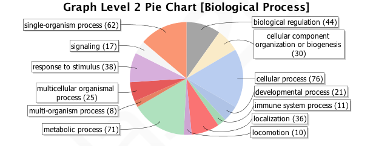

## Here is a simplified GO Map

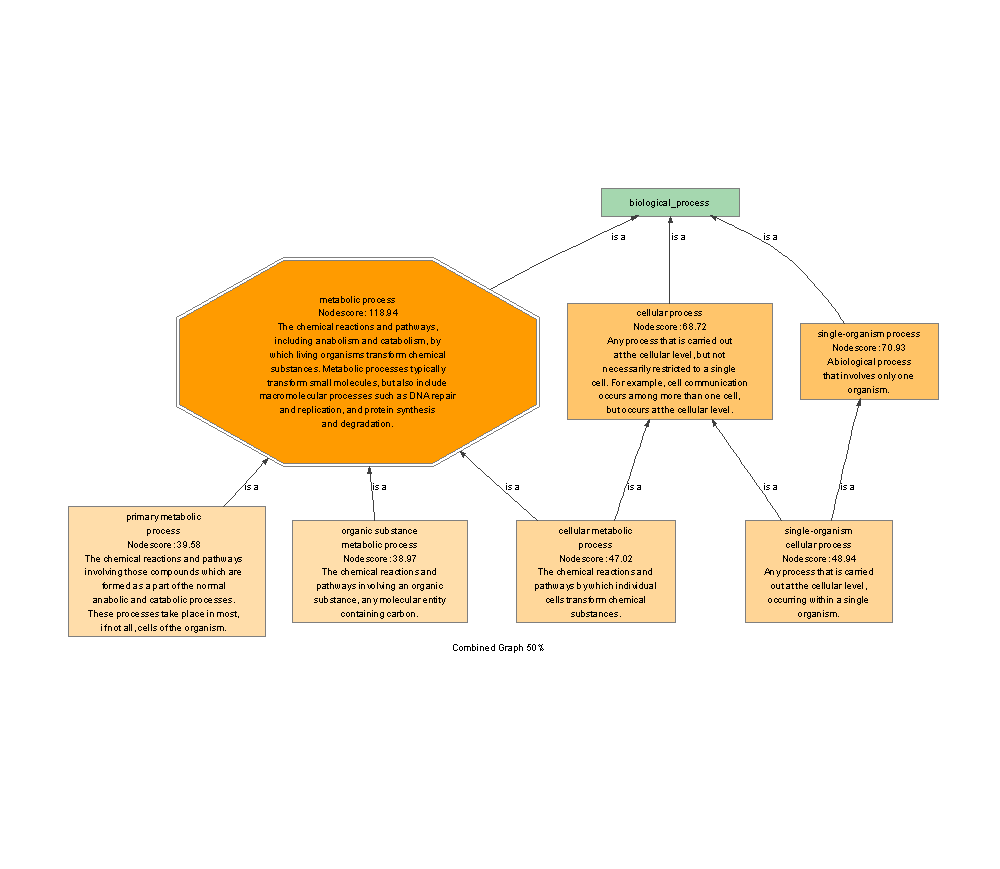